# Stats 20, W23 – Homework 1

Haojie Liu – 905943123

01/19/23

## Question 1

### (a)

“**Sometimes you have to make the hardest climb to see the most beautiful sunrise.** I read that once on an old lady’s decorative pillow, but it is really how I feel today. I’ve climbed a very weird and rocky mountain, and it was a pain in the ass, and my legs are tired, and I’m starving. But *the sun is rising over a sea of love and waffles and possibility.* So *I’m just gonna relax and take a deep breath and enjoy this view for as long as I possibly can.”* – Leslie Knope (from *Parks and Recreation*)

### (b)

| Homework | Midterm | Final Exam | Final Project |
| --- | --- | --- | --- |
| 18% | 30% | 40% | 12% |

### (c)

- 2022
  - Fall
    - Stats 15
    - Stats 100A
    - Hist 8A
  - Winter
    - Stats 20
    - Math 115A
    - CS 32
    - CS M51A

### (d)

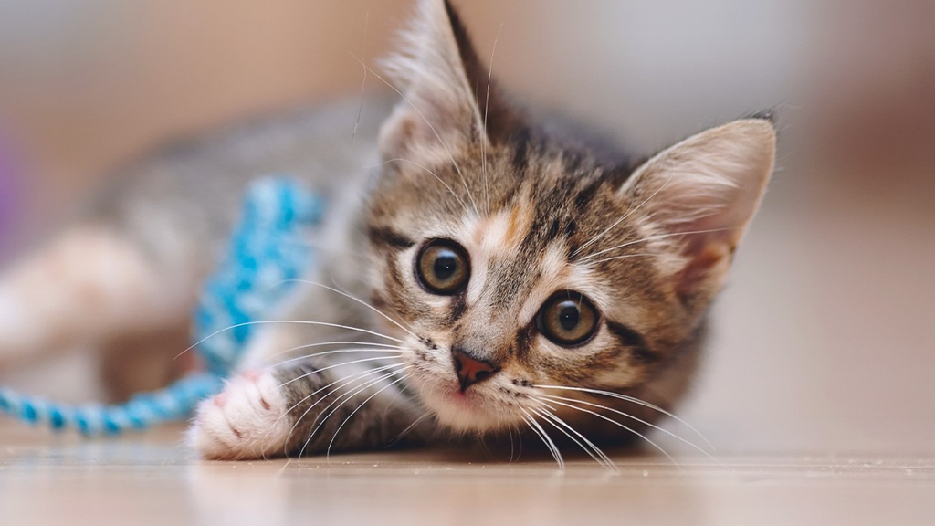

## Question 2

### (a)

The video inspires the audience about how computer will act like if gives bad instruction. The program need to be as clear as possible, and lead the computer to the right direction.

### (b)

First, we need to get a piece of 1/3 pound ground beef, a piece of cheese and two piece of bread. Second, we need to put the ground beef onto the grill pan and cook for 90 seconds then flip it to the other side and cook for another 90 seconds. Take it out after. Then, we have to put the two pieces of bread onto the grill pan and cook for 30 seconds. Take it out after. Lastly, take a piece of bread and put it on table, then place the grilled beef from step 2 and lay it on top of the bread which I placed on the table. Place one cheese piece on top of it and then place the grilled bread on top of the cheese with the grilled side face down.

## Question 3

### (a)

```r
(6^8)/(16^5)
```

```
## [1] 1.601807
```

```r
101^(-8/7)
```

```
## [1] 0.005120908
```

```r
8+(3*pi)-3+((4/2)*(-1))
```

```
## [1] 12.42478
```

1. 1.601807
2. 0.005120908
3. 12.42478

### (b)

```r
log(54,base =2)
```

```
## [1] 5.754888
```

```r
exp(exp(sqrt(2)))
```

```
## [1] 61.14514
```

```r
(exp(pi)+exp(-pi))/2
```

```
## [1] 11.59195
```

1. 5.754888
2. 61.14514
3. 11.59195

### (c)

```r
119%/%25
```

```
## [1] 4
```

```r
119%%25
```

```
## [1] 19
```

1. 4
2. 19

## Question 4

### (a)

```r
vol_1 <- (4/3)*pi*(1^3)
vol_4 <- (4/3)*pi*(4^3)
vol_1
```

```
## [1] 4.18879
```

```r
vol_4
```

```
## [1] 268.0826
```

1. 4.18879
2. 268.0826

### (b)

```r
vol_sphere <- function(r=1){
(4/3)*pi*(r^3)
}
```

### (c)

```r
vol_sphere()==vol_1
```

```
## [1] TRUE
```

```r
vol_sphere(4)==vol_4
```

```
## [1] TRUE
```

1. True
2. True

## Question 5

### (a)

```r
z_prop<- function(x,n,p0){
  ((x/n)-p0)/(sqrt((p0*(1-p0))/n))
}

z_prop(10,13,0.6)
```

```
## [1] 1.245505
```

### (b)

```r
z_prop(10,13,0.6)
```

```
## [1] 1.245505
```

### (c)

```r
z_prop(30,39,0.6)
```

```
## [1] 2.157277
```

## Question 6

### (a)

```r
lease_calc <- function(msrp,price,down,n=36,res=0.6,mf=0.001,tax=0.095){
  cap_cost<-price-down
  res_val <- msrp*res
  monthly_dep <- (cap_cost-res_val)/n
  monthly_fine_char <- (cap_cost+res_val)*mf
  sub_total <- monthly_dep+monthly_fine_char
  total <- sub_total+(sub_total*tax)
  total
}
```

### (b)

```r
lease_calc(31495,29895,2500,36,0.52,0.0016,0.095)
```

```
## [1] 411.8079
```

## Question 7

### (a)

The minimum number of coins required to equal 47 cents is $0.25+0.1*2+0.01*2$, 5 coins in total. To get this number, I first divide the total by the largest coin and keep the reminder, then use the reminder to divide the following large coin, and so on.

### (b)

To get the number above, I first divide the total by the largest coin and keep the reminder, then use the reminder to divide the following large coin, and so on.

### (c)

```r
get_minimum_coins<- function(n){
  n<-n*100
  count <- 0
  count <- count+(n%/%25)

  n <- n%%25
  count <- count+(n%/%10)

  n <- n%%10
  count <- count+(n%/%5)

  n <- n%%5
  count <- count+(n%/%1)
  count
}
```

### (d)

```r
get_minimum_coins(0.31)
```

```
## [1] 3
```

```r
get_minimum_coins(0.48)
```

```
## [1] 6
```

```r
get_minimum_coins(1.39)
```

```
## [1] 10
```

1. 3
2. 6
3. 10

### (e)

```r
get_minimum_coins(0.99)
```

```
## [1] 9
```

## Question 8

```r
x <- 3
y <- 4
exp1 <- function() {
  x^y
}
exp2 <- function(x = 2) {
  x^y
}
exp_y <- function(x) {
  function(y) {
    x^y
  }
}
```

### (a)

When printing out exp1(), there is no default value set in the function, therefore, it will use the number that already given to x and y. However, in exp2(), there is a default value that is already given to x. Therefore, when we running this function, x will be determined as 2 instead of 3.

### (b)

```r
exp_y <- function() {
  15^y
}


exp_y()
```

```
## [1] 50625
```